# Codebook and Descriptive Analysis of

Confirmed Cases and Deaths by County

NYU A3SR

```r
if(!requireNamespace("dplyr"))
  install.packages("dplyr", repos = "https://cloud.r-project.org")
if(!requireNamespace("data.table"))
  install.packages("data.table", repos = "https://cloud.r-project.org")
if(!requireNamespace("here"))
  install.packages("here", repos = "https://cloud.r-project.org")
if(!requireNamespace("ggplot2"))
  install.packages("ggplot2", repos = "https://cloud.r-project.org")
require(data.table)
require(dplyr)
library(here)
require(ggplot2)
```

## Introduction

The `usa-facts` folder contains data of confirmed cases and deaths of all counties in the United States, provided by [USA FACTS](https://usafacts.org/visualizations/coronavirus-covid-19-spread-map/). The data are updated on a daily basis and are stored in folders with date&time stamps.

Please use this codebook document as a reference to various procedures, such as data processing and variable naming.

## Creating the tidy datafile

1. Daily nation-wide total confirmed cases
2. Most recent confirmed cases by county (as of 03-27-2020)

## Descriptive Analysis

### Data Structure

Data are ordered in time series. Starting from Jan. 22, 2020 (1/22/2020), county-level confirmed cases were recorded daily. Each value time stamp variables is cumulative. For example, the value of confirmed cases in Queens, NY on Mar. 27, 2020 is calculated by adding cumulative confirmed cases on Mar. 26, 2020 with new cases confirmed on Mar. 27. Therefore, to get daily new cases, we can simply subtract the value on a particular day with the value in the previous day.

#### Overview

Top 5 rows of raw data

```r
head(dat, 5)
```

| countyFIPS | County Name | State | stateFIPS | 1/22/2020 | 1/23/2020 | 1/24/2020 | 1/25/2020 | 1/26/2020 | 1/27/2020 | 1/28/2020 | 1/29/2020 | 1/30/2020 | 1/31/2020 | 2/1/2020 | 2/2/2020 | 2/3/2020 | 2/4/2020 | 2/5/2020 | 2/6/2020 | 2/7/2020 | 2/8/2020 | 2/9/2020 | 2/10/2020 | 2/11/2020 | 2/12/2020 | 2/13/2020 | 2/14/2020 | 2/15/2020 | 2/16/2020 | … |
| --- | --- | --- | --- | --- | --- | --- | --- | --- | --- | --- | --- | --- | --- | --- | --- | --- | --- | --- | --- | --- | --- | --- | --- | --- | --- | --- | --- | --- | --- | --- |
| 0 | Statewide Unallocated | AL | 1 | 0 | 0 | 0 | 0 | 0 | 0 | 0 | 0 | 0 | 0 | 0 | 0 | 0 | 0 | 0 | 0 | 0 | 0 | 0 | 0 | 0 | 0 | 0 | 0 | 0 | 0 | … |
| 1001 | Autauga County | AL | 1 | 0 | 0 | 0 | 0 | 0 | 0 | 0 | 0 | 0 | 0 | 0 | 0 | 0 | 0 | 0 | 0 | 0 | 0 | 0 | 0 | 0 | 0 | 0 | 0 | 0 | 0 | … |
| 1003 | Baldwin County | AL | 1 | 0 | 0 | 0 | 0 | 0 | 0 | 0 | 0 | 0 | 0 | 0 | 0 | 0 | 0 | 0 | 0 | 0 | 0 | 0 | 0 | 0 | 0 | 0 | 0 | 0 | 0 | … |
| 1005 | Barbour County | AL | 1 | 0 | 0 | 0 | 0 | 0 | 0 | 0 | 0 | 0 | 0 | 0 | 0 | 0 | 0 | 0 | 0 | 0 | 0 | 0 | 0 | 0 | 0 | 0 | 0 | 0 | 0 | … |
| 1007 | Bibb County | AL | 1 | 0 | 0 | 0 | 0 | 0 | 0 | 0 | 0 | 0 | 0 | 0 | 0 | 0 | 0 | 0 | 0 | 0 | 0 | 0 | 0 | 0 | 0 | 0 | 0 | 0 | 0 | … |

Bottom 5 rows of raw data

```r
tail(dat, 5)
```

| countyFIPS | County Name | State | stateFIPS | 1/22/2020 | 1/23/2020 | 1/24/2020 | 1/25/2020 | 1/26/2020 | 1/27/2020 | 1/28/2020 | 1/29/2020 | 1/30/2020 | 1/31/2020 | 2/1/2020 | 2/2/2020 | 2/3/2020 | 2/4/2020 | 2/5/2020 | 2/6/2020 | 2/7/2020 | 2/8/2020 | 2/9/2020 | 2/10/2020 | 2/11/2020 | 2/12/2020 | 2/13/2020 | 2/14/2020 | 2/15/2020 | 2/16/2020 | … |
| --- | --- | --- | --- | --- | --- | --- | --- | --- | --- | --- | --- | --- | --- | --- | --- | --- | --- | --- | --- | --- | --- | --- | --- | --- | --- | --- | --- | --- | --- | --- |
| 56037 | Sweetwater County | WY | 56 | 0 | 0 | 0 | 0 | 0 | 0 | 0 | 0 | 0 | 0 | 0 | 0 | 0 | 0 | 0 | 0 | 0 | 0 | 0 | 0 | 0 | 0 | 0 | 0 | 0 | 0 | … |
| 56039 | Teton County | WY | 56 | 0 | 0 | 0 | 0 | 0 | 0 | 0 | 0 | 0 | 0 | 0 | 0 | 0 | 0 | 0 | 0 | 0 | 0 | 0 | 0 | 0 | 0 | 0 | 0 | 0 | 0 | … |
| 56041 | Uinta County | WY | 56 | 0 | 0 | 0 | 0 | 0 | 0 | 0 | 0 | 0 | 0 | 0 | 0 | 0 | 0 | 0 | 0 | 0 | 0 | 0 | 0 | 0 | 0 | 0 | 0 | 0 | 0 | … |
| 56043 | Washakie County | WY | 56 | 0 | 0 | 0 | 0 | 0 | 0 | 0 | 0 | 0 | 0 | 0 | 0 | 0 | 0 | 0 | 0 | 0 | 0 | 0 | 0 | 0 | 0 | 0 | 0 | 0 | 0 | … |
| 56045 | Weston County | WY | 56 | 0 | 0 | 0 | 0 | 0 | 0 | 0 | 0 | 0 | 0 | 0 | 0 | 0 | 0 | 0 | 0 | 0 | 0 | 0 | 0 | 0 | 0 | 0 | 0 | 0 | 0 | … |

#### Daily Nation-wide Total

A summary table of nation-wide daily total confirmed cases is attached.

```r
# Create a table showing daily total confirmed cases, nation-wide
date <- as.Date(paste("0", colnames(dat[, 5:70]) , sep = ""), "%m/%d/%y")

total_confirmed_daily <- lapply(dat[, 5:70], FUN = sum)
total_confirmed_daily <- t(as.matrix(as.data.frame(total_confirmed_daily)))
total_confirmed_daily <- data.frame(date = date,
                                    total_confirmed = total_confirmed_daily)
row.names(total_confirmed_daily) <- NULL

total_confirmed_daily
```

| date | total_confirmed |
| --- | --- |
| 2020-01-22 | 1 |
| 2020-01-23 | 1 |
| 2020-01-24 | 2 |
| 2020-01-25 | 2 |
| 2020-01-26 | 5 |
| 2020-01-27 | 5 |
| 2020-01-28 | 5 |
| 2020-01-29 | 5 |
| 2020-01-30 | 5 |
| 2020-01-31 | 7 |

[output cut: 56 more lines]

#### Most Recent by County

```r
# Create a tidy datafile to include only
# county, state, and most recent confirmed cases.
total_cases <- total_confirmed_daily[nrow(total_confirmed_daily), 2]
dat_most_recent <- dat %>%
  select(
    "county" = "County Name",
    "state" = "State",
    "most_recent" = "3/27/2020"
  ) %>%
  group_by(state) %>%
  arrange(desc(most_recent)) %>%
  mutate(
    percentage_of_total = round(most_recent / total_cases, digits = 3)
  )

dat_most_recent
```

| county | state | most_recent | percentage_of_total |
| --- | --- | --- | --- |
| Queens County | NY | 8214 | 0.080 |
| Westchester County | NY | 7187 | 0.070 |
| Kings County | NY | 6750 | 0.066 |
| Nassau County | NY | 4657 | 0.046 |
| Bronx County | NY | 4655 | 0.046 |
| New York County | NY | 4478 | 0.044 |
| Suffolk County | NY | 3386 | 0.033 |
| Cook County | IL | 2239 | 0.022 |
| Statewide Unallocated | NJ | 1984 | 0.019 |
| King County | WA | 1828 | 0.018 |

[output cut: 3187 more lines]

#### Raw Data

```r
# Get an overview on the data
glimpse_dat <- glimpse(dat)
```

```
## Observations: 3,197
## Variables: 70
## $ countyFIPS    <int> 0, 1001, 1003, 1005, 1007, 1009, 1011, 1013, 1015, 10...
## $ `County Name` <chr> "Statewide Unallocated", "Autauga County", "Baldwin C...
## $ State         <chr> "AL", "AL", "AL", "AL", "AL", "AL", "AL", "AL", "AL",...
## $ stateFIPS     <int> 1, 1, 1, 1, 1, 1, 1, 1, 1, 1, 1, 1, 1, 1, 1, 1, 1, 1,...
## $ `1/22/2020`   <int> 0, 0, 0, 0, 0, 0, 0, 0, 0, 0, 0, 0, 0, 0, 0, 0, 0, 0,...
## $ `1/23/2020`   <int> 0, 0, 0, 0, 0, 0, 0, 0, 0, 0, 0, 0, 0, 0, 0, 0, 0, 0,...
## $ `1/24/2020`   <int> 0, 0, 0, 0, 0, 0, 0, 0, 0, 0, 0, 0, 0, 0, 0, 0, 0, 0,...
## $ `1/25/2020`   <int> 0, 0, 0, 0, 0, 0, 0, 0, 0, 0, 0, 0, 0, 0, 0, 0, 0, 0,...
## $ `1/26/2020`   <int> 0, 0, 0, 0, 0, 0, 0, 0, 0, 0, 0, 0, 0, 0, 0, 0, 0, 0,...
## $ `1/27/2020`   <int> 0, 0, 0, 0, 0, 0, 0, 0, 0, 0, 0, 0, 0, 0, 0, 0, 0, 0,...
## $ `1/28/2020`   <int> 0, 0, 0, 0, 0, 0, 0, 0, 0, 0, 0, 0, 0, 0, 0, 0, 0, 0,...
## $ `1/29/2020`   <int> 0, 0, 0, 0, 0, 0, 0, 0, 0, 0, 0, 0, 0, 0, 0, 0, 0, 0,...
## $ `1/30/2020`   <int> 0, 0, 0, 0, 0, 0, 0, 0, 0, 0, 0, 0, 0, 0, 0, 0, 0, 0,...
```

[output cut: 57 more lines]

```r
glimpse_dat
```

| countyFIPS | County Name | State | stateFIPS | 1/22/2020 | 1/23/2020 | 1/24/2020 | 1/25/2020 | 1/26/2020 | 1/27/2020 | 1/28/2020 | 1/29/2020 | 1/30/2020 | 1/31/2020 | 2/1/2020 | 2/2/2020 | 2/3/2020 | 2/4/2020 | 2/5/2020 | 2/6/2020 | 2/7/2020 | 2/8/2020 | 2/9/2020 | 2/10/2020 | 2/11/2020 | 2/12/2020 | 2/13/2020 | 2/14/2020 | 2/15/2020 | 2/16/2020 | … |
| --- | --- | --- | --- | --- | --- | --- | --- | --- | --- | --- | --- | --- | --- | --- | --- | --- | --- | --- | --- | --- | --- | --- | --- | --- | --- | --- | --- | --- | --- | --- |
| 0 | Statewide Unallocated | AL | 1 | 0 | 0 | 0 | 0 | 0 | 0 | 0 | 0 | 0 | 0 | 0 | 0 | 0 | 0 | 0 | 0 | 0 | 0 | 0 | 0 | 0 | 0 | 0 | 0 | 0 | 0 | … |
| 1001 | Autauga County | AL | 1 | 0 | 0 | 0 | 0 | 0 | 0 | 0 | 0 | 0 | 0 | 0 | 0 | 0 | 0 | 0 | 0 | 0 | 0 | 0 | 0 | 0 | 0 | 0 | 0 | 0 | 0 | … |
| 1003 | Baldwin County | AL | 1 | 0 | 0 | 0 | 0 | 0 | 0 | 0 | 0 | 0 | 0 | 0 | 0 | 0 | 0 | 0 | 0 | 0 | 0 | 0 | 0 | 0 | 0 | 0 | 0 | 0 | 0 | … |
| 1005 | Barbour County | AL | 1 | 0 | 0 | 0 | 0 | 0 | 0 | 0 | 0 | 0 | 0 | 0 | 0 | 0 | 0 | 0 | 0 | 0 | 0 | 0 | 0 | 0 | 0 | 0 | 0 | 0 | 0 | … |
| 1007 | Bibb County | AL | 1 | 0 | 0 | 0 | 0 | 0 | 0 | 0 | 0 | 0 | 0 | 0 | 0 | 0 | 0 | 0 | 0 | 0 | 0 | 0 | 0 | 0 | 0 | 0 | 0 | 0 | 0 | … |
| 1009 | Blount County | AL | 1 | 0 | 0 | 0 | 0 | 0 | 0 | 0 | 0 | 0 | 0 | 0 | 0 | 0 | 0 | 0 | 0 | 0 | 0 | 0 | 0 | 0 | 0 | 0 | 0 | 0 | 0 | … |
| 1011 | Bullock County | AL | 1 | 0 | 0 | 0 | 0 | 0 | 0 | 0 | 0 | 0 | 0 | 0 | 0 | 0 | 0 | 0 | 0 | 0 | 0 | 0 | 0 | 0 | 0 | 0 | 0 | 0 | 0 | … |
| 1013 | Butler County | AL | 1 | 0 | 0 | 0 | 0 | 0 | 0 | 0 | 0 | 0 | 0 | 0 | 0 | 0 | 0 | 0 | 0 | 0 | 0 | 0 | 0 | 0 | 0 | 0 | 0 | 0 | 0 | … |
| 1015 | Calhoun County | AL | 1 | 0 | 0 | 0 | 0 | 0 | 0 | 0 | 0 | 0 | 0 | 0 | 0 | 0 | 0 | 0 | 0 | 0 | 0 | 0 | 0 | 0 | 0 | 0 | 0 | 0 | 0 | … |
| 1017 | Chambers County | AL | 1 | 0 | 0 | 0 | 0 | 0 | 0 | 0 | 0 | 0 | 0 | 0 | 0 | 0 | 0 | 0 | 0 | 0 | 0 | 0 | 0 | 0 | 0 | 0 | 0 | 0 | 0 | … |

[output cut: 3187 more lines]

### Basic Visualization

#### Daily Nation-wide Total

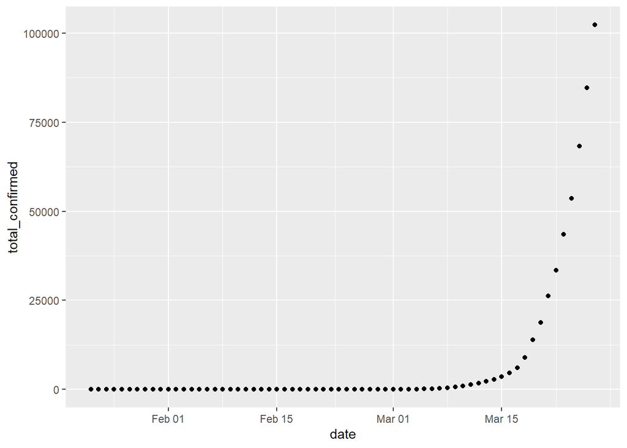

```r
ggplot(total_confirmed_daily, aes(x = date, y = total_confirmed)) +
  geom_point()
```